# Frequentist-Regularized-Regression

Duong Trinh

2022-08-10

$\newcommand{\mathbbm}[1]{\mathbb{#1}}$

```r
# tidyverse (includes ggplot2, dplyr, tidyr), glmnet, ranger, xgboost, mlr3verse, grf, causalforest, policytree, GenericML, DoubleML
```

# 1 Introduction

Originally, regularization can be viewed as a constraint on the model space. Consider a classic linear regression model with normally distributed errors

$$\begin{equation}
\tag{1}
\mathbf{y}= \mathbf{X}\mathbf{\beta}+\mathbf{\epsilon}, \quad \mathbf{\epsilon} \sim N\left(\mathbf{0},\sigma_{\epsilon}^{2} \mathbf{I}\right)
\end{equation}$$

The corresponding regularized maximum likelihood optimization problem is defined as
$$\begin{equation}
\tag{2}
\underset{\mathbf{\beta}}{\text{minimize}} \quad\|\mathbf{y}-\mathbf{X}\mathbf{\beta}\|_{2}^{2} \quad \text{subject to} \quad \phi(\mathbf{\beta}) \leq s
\end{equation}$$

of which the solution could be written in the alternative form

$$\begin{equation}
\tag{3}
\hat{\mathbf{\beta}} = \underset{\mathbf{\beta}}{\text{argmin}} \quad\|\mathbf{y}-\mathbf{X}\mathbf{\beta}\|_{2}^{2} + \lambda \phi(\mathbf{\beta})
\end{equation}$$

where:

- $\mathbf{y}$ is the vector of observed outcomes, $\mathbf{X}$ is a design matrix, $\mathbf{\beta}$ are the model parameters.
- $s$ in (2) or $\lambda$ in (3) is a tuning parameter (hyper-parameter) controlling the strength of the penalty. (the bias-variance trade-off).
- $\phi(\mathbf{\beta})$ is a regularization term (penalty).

In general, a separable penalty is of the form: $\phi(\mathbf{\beta}) = \sum_{j = 1}^{p}\phi(\beta_j)$, where $\phi(\beta_j)$ is a penalty function applied for each component $\beta_j$. In fact, each appropriate choice of the regularization term is associated with a desirable estimator in (1). Mathematically, a regularized solution can be defined by constraining the topology of a search space to a ball.

## 1.1 Lasso

The Lasso (Least Absolute Shrinkage and Selection Operator, Tibshirani (1996)) penalizes the sum of the absolute values of the coefficients (L1 norm):
$$\hat{\beta} = \text{argmin} \quad\|\mathbf{y}-\mathbf{X}\mathbf{\beta}\|_{2}^{2} + \frac{\lambda}{n} \| \beta \|_1$$

where $L_1$ norm $\| \beta \|_1 = \sum_{i = 1}^{p} \mid\beta_i\mid$

### Square root Lasso

$$\hat{\beta} = \text{argmin} \quad \sqrt{\|\mathbf{y}-\mathbf{X}\mathbf{\beta}\|_{2}^{2}} + \frac{\lambda}{n} \| \beta \|_1$$

## 1.2 Ridge

$$\hat{\beta} = \text{argmin} \quad\|\mathbf{y}-\mathbf{X}\mathbf{\beta}\|_{2}^{2} + \frac{\lambda}{n} \| \beta \|_2$$

where $L_2$ norm $\| \beta \|_2 = \sum_{i = 1}^{p} \beta_i ^ 2$

## 1.3 Elastic Net

## 1.4 Standardization

- We should always standardize the predictors

# 2 Illustration

Reference Manual:

- [Package `glmnet`](https://cran.r-project.org/web/packages/glmnet/index.html)
- [An Introduction to `glmnet`](https://glmnet.stanford.edu/articles/glmnet.html)

```r
# install.packages("glmnet", dependencies = TRUE)
library(glmnet)
# install.packages("caret", dependencies = TRUE) # clasification and regression training (for pre-processing, data splitting)
library(caret)
library(tidyverse)
library(ggplot2)
```

## 2.1 Real dataset

```r
# data(QuickStartExample)
# x <- QuickStartExample$x
# y <- QuickStartExample$y
#
# fit <- glmnet(x, y)
#
# plot(fit)
# print(fit)
#
# cv <- cv.glmnet(x, y)
# plot(cv)
# ggplot(data.frame(beta = 1:(ncol(x)+1), value = coef(cv, s = "lambda.min")[,"s1"]),
#        aes(x = beta, y = value)) +
#   geom_col()

# ggplot(data.frame(beta = 1:(ncol(x)+1), value = coef(cv, s = "lambda.1se")[,"s1"]),
#        aes(x = beta, y = value)) +
#   geom_col()
```

## 2.2 Monte Carlo study

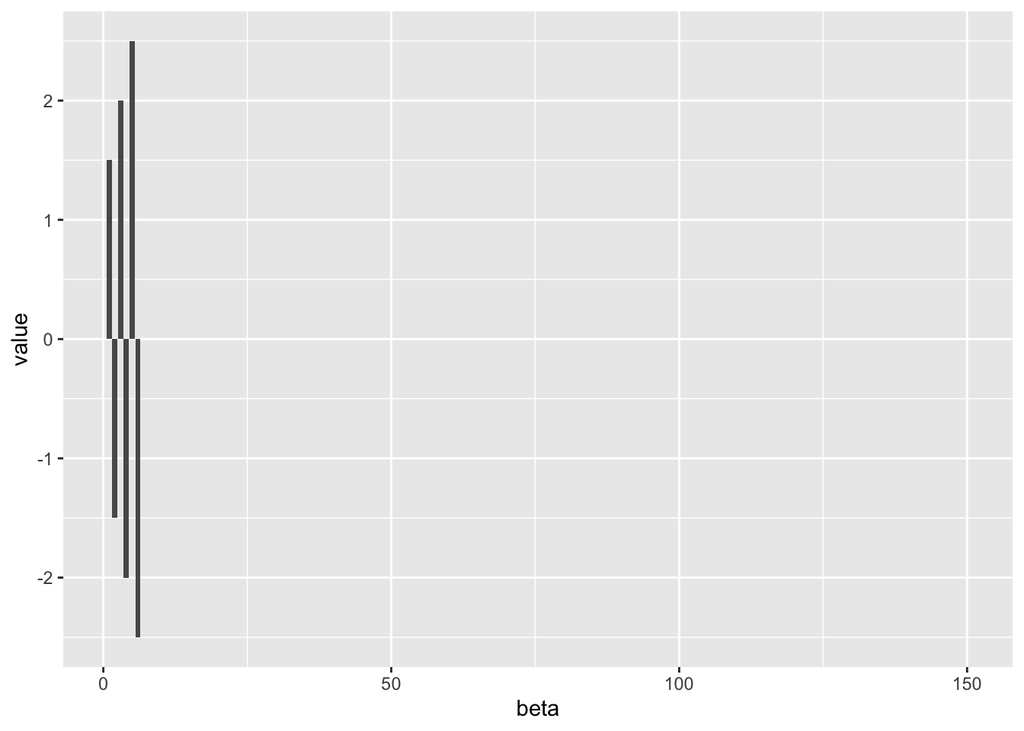

```r
# library(pracma) # for a (non-symmetric) Toeplitz matrix
GenRegr <- function(n,p,options) {
  # Generate predictors x
  if (options.corr == 0) {# Uncorrelated predictors
    x = matrix(rnorm(n*p),n,p)
  }
  else if (options.corr == 1) {# Spatially ncorrelated predictors
    C = toeplitz(options.rho^(0:(p-1)))
    x = matrix(rnorm(n*p),n,p)*chol(C)
  }
  else {
    print('Wrong choice of options.corr')
  }

  x <- data.matrix(sapply(data.frame(x), function(x) {(x-mean(x))/sd(x)})) # Standardize x

  # Generate coefficients
  beta <- rep(0,p)
  beta[1:6] <- c(1.5,-1.5,2,-2,2.5,-2.5)

  if (options.corr == 0) {
    signal_y <- sum(beta^2)
  }
  else if (options.corr == 1) {
    signal_y <- sum((chol(C)%*%beta)^2)
  }

  c <- signal_y*((1-options.R2)/options.R2) # mean(sigmasq) is c to obtain desirable options.R2 (or SNR)

  # Generate epsilon
  if (options.epsilon == 0) { # iid error
    sigmasq <- c
  }
  else if (options.epsilon == 1) {
    temp = (x%*%beta)
    sigmasq = c*temp/mean(temp)
  }

  epsilon = sqrt(sigmasq) * rnorm(n)

  # Generate y
  y = x%*%beta + epsilon

  return(list(y = y, x = x, beta = beta, sigmasq = sigmasq))
}

# DGP1
set.seed(2907)
n = 100
p = 150
options.corr = 0
options.R2 = 0.8
options.epsilon = 0
options.rho = NA

df <- GenRegr(n, p, options)

y <- df$y
X <- df$x
beta_true <-  df$beta
sigmasq_true <- df$sigmasq

dat <- data.frame(y,X)


# beta_names <- map_chr(1:length(beta_true),~paste0("b",.x))
# df_beta <- data.frame(beta = factor(beta_names, levels = beta_names), value = beta_true)

df_beta <- data.frame(beta = 1:length(beta_true), value = beta_true)

ggplot(df_beta, aes(x = beta, y = value)) +
  geom_col()
```

```r
# # WangDesign
#
# n_training <- n
# n <- n_training + n_test
#
# x <- matrix(rnorm(n*p),n,p)
# gamma <- rep(0,p)
# gamma[sample(1:p, size = s0, replace = FALSE)] = 1
# beta0 <- rep(0,p)
# beta0[which(gamma==1)] <- beta_value
```

```r
# Data Partitioning
set.seed(100)
index <-  sample(1:nrow(dat), 0.7*nrow(dat))

str(index)
```

```
##  int [1:70] 74 89 78 23 86 70 4 55 95 7 ...
```

```r
train <- dat[index,] # 70x(p+1)
test <- dat[-index,] # 30x(p+1)

cols <- names(dat)[2:(p+1)]
# Scaling the numeric features
pre_proc_val <- preProcess(train[,cols], method = c("center","scale"))

train[,cols] <- predict(pre_proc_val,train[,cols])
test[,cols] <- predict(pre_proc_val,test[,cols])

# summary(train)
# summary(test)
```

### Estimation

```r
library(glmnet)

x <- as.matrix(train[,cols])
y_train = train$y

x_test <- as.matrix(test[,cols])
y_test = test$y


ridge_reg <- function(x,y,x_test) {
  cv_pen <- cv.glmnet(x, y, alpha = 0, nlambda = 100,
                      family = 'gaussian', standardize = TRUE, nfolds = 5)
  run_pen <- glmnet(x, y, alpha = 0, lambda = cv_pen$lambda,
                    family = 'gaussian', standardize = TRUE, nfolds = 5)
  solution_path <- Matrix(run_pen$beta, sparse = TRUE)
  colnames(solution_path) <- cv_pen$lambda
  lambda.min_idx <- which.min(abs(cv_pen$lambda-cv_pen$lambda.min))
  beta.cv <- solution_path[,lambda.min_idx]

  y.fit <- x_test%*%beta.cv

  return(list(beta.cv = beta.cv, y.fit = y.fit))
}

lasso_reg <- function(x,y,x_test) {
  cv_pen <- cv.glmnet(x, y, alpha = 1, nlambda = 100,
                      family = 'gaussian', standardize = TRUE, nfolds = 5)
  run_pen <- glmnet(x, y, alpha = 1, lambda = cv_pen$lambda,
                    family = 'gaussian', standardize = TRUE, nfolds = 5)
  solution_path <- Matrix(run_pen$beta, sparse = TRUE)
  colnames(solution_path) <- cv_pen$lambda
  lambda.min_idx <- which.min(abs(cv_pen$lambda-cv_pen$lambda.min))
  beta.cv <- solution_path[,lambda.min_idx]

  active <- rep(FALSE, ncol(x))
  active[which(beta.cv!=0)] <- TRUE
  xnew <- x[,active]
  beta.ols <- solve(t(xnew)%*%xnew)%*%t(xnew)%*%y
  beta.debiased <- rep(0, ncol(x))
  beta.debiased[active] <- beta.ols

  str(t(xnew)%*%xnew)
  y.fit <- x_test%*%beta.cv

  return(list(beta.cv = beta.cv, beta.debiased = beta.debiased, y.fit = y.fit))
}

elnet_reg <- function(x,y,x_test) {
  cv_pen <- cv.glmnet(x, y, alpha = 0.3, nlambda = 100,
                      family = 'gaussian', standardize = TRUE, nfolds = 5)
  run_pen <- glmnet(x, y, alpha = 0.3, lambda = cv_pen$lambda,
                    family = 'gaussian', standardize = TRUE, nfolds = 5)
  solution_path <- Matrix(run_pen$beta, sparse = TRUE)
  colnames(solution_path) <- cv_pen$lambda
  lambda.min_idx <- which.min(abs(cv_pen$lambda-cv_pen$lambda.min))
  beta.cv <- solution_path[,lambda.min_idx]

  active <- rep(FALSE, ncol(x))
  active[which(beta.cv!=0)] <- TRUE
  xnew <- x[,active]
  beta.ols <- solve(t(xnew)%*%xnew)%*%t(xnew)%*%y
  beta.debiased <- rep(0, ncol(x))
  beta.debiased[active] <- beta.ols

  str(t(xnew)%*%xnew)
  y.fit <- x_test%*%beta.cv

  return(list(beta.cv = beta.cv, beta.debiased = beta.debiased, y.fit = y.fit))
}


# # ELASTIC NET
# # Set training control
# train_cont <- trainControl(method = "repeatedcv",
#                               number = 10,
#                               repeats = 5,
#                               search = "random",
#                               verboseIter = TRUE)
#
# # Train the model
# elastic_reg <- train(y ~ .,
#                            data = train,
#                            method = "glmnet",
#                            preProcess = c("center", "scale"),
#                            tuneLength = 10,
#                            trControl = train_cont)
#
# # Optimal tuning parameter
# elastic_reg$bestTune



resRidge <- ridge_reg(x,y_train,x_test)
resLasso <- lasso_reg(x,y_train,x_test)
```

```
##  num [1:35, 1:35] 69 -3.4231 0.0561 -4.4414 3.9652 ...
##  - attr(*, "dimnames")=List of 2
##   ..$ : chr [1:35] "X2" "X3" "X4" "X5" ...
##   ..$ : chr [1:35] "X2" "X3" "X4" "X5" ...
```

```r
resElnet <- elnet_reg(x,y_train,x_test)
```

```
##  num [1:62, 1:62] 69 18.35 -15.55 -2.33 -14.83 ...
##  - attr(*, "dimnames")=List of 2
##   ..$ : chr [1:62] "X1" "X2" "X3" "X4" ...
##   ..$ : chr [1:62] "X1" "X2" "X3" "X4" ...
```

### Perfomance Metrics

$$R^2 = 1 - \frac{SSE}{SST} = 1 - \frac{\sum(y_i - \hat{y_i})^2}{\sum(y_i - \bar{y})^2}$$

```r
# Prediction
RMSE <- function(y_test,y.fit) {
  sqrt(mean(y_test-y.fit-mean(y_test))^2)
}

list_yfit <- list(resRidge$y.fit, resLasso$y.fit, resElnet$y.fit)

library(purrr)
map_dbl(list_yfit, ~RMSE(y_test,.x))
```

```
## [1] 0.00334102 0.24122523 0.27481194
```

```r
# Variable Selection
mse <- function(true,fit) {
  mean(fit-true)^2
}

bias <- function(true,fit) {
  mean(abs(fit-true))
}

list_betafit <- list(resRidge$beta.cv, resLasso$beta.cv, resElnet$beta.cv, resLasso$beta.debiased, resElnet$beta.debiased)
library(purrr)
map_dbl(list_betafit, ~mse(beta_true,.x))
```

```
## [1] 7.034638e-06 7.131331e-06 7.869738e-05 6.366999e-05 9.113556e-04
```

```r
map_dbl(list_betafit, ~bias(beta_true,.x))
```

```
## [1] 0.12681100 0.06556196 0.10125328 0.10249696 0.13649989
```

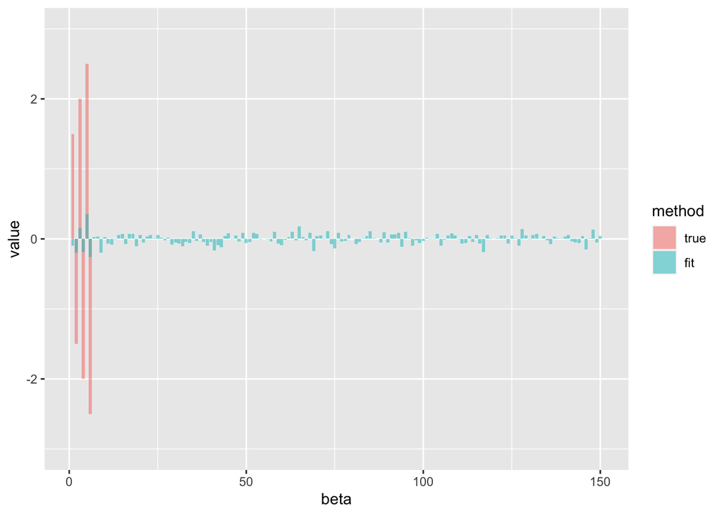

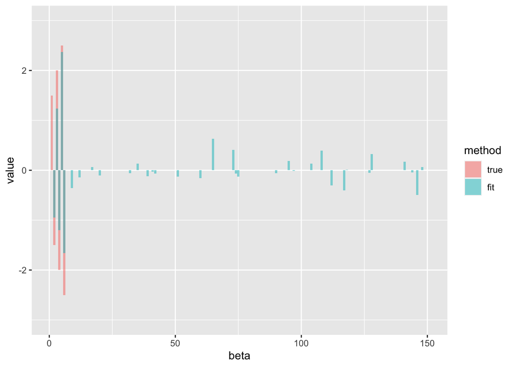

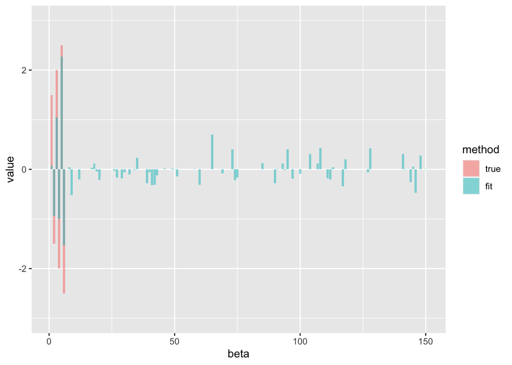

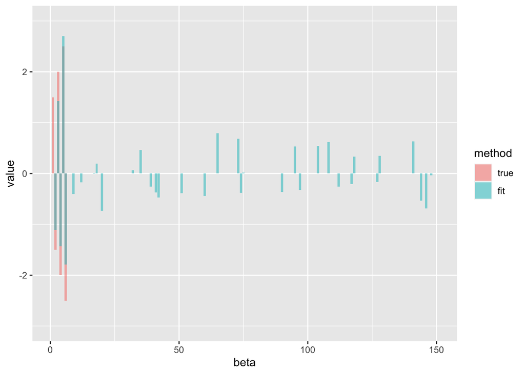

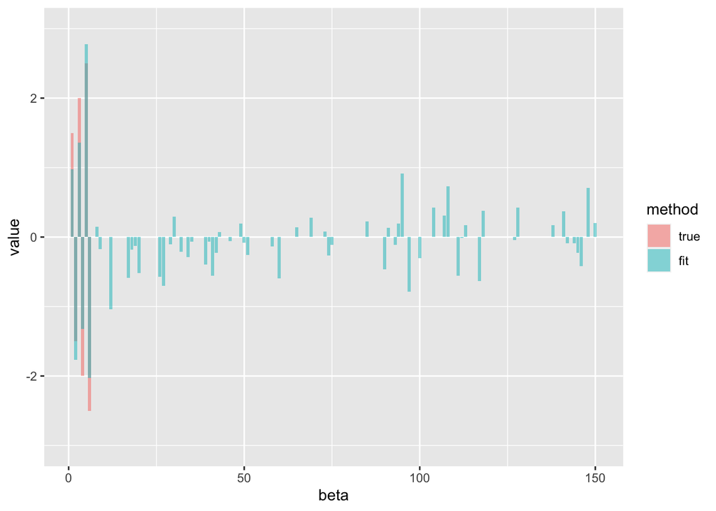

```r
plot.coef <- function(fit){
  df_beta <- data.frame(beta = 1:length(fit), true = beta_true, fit = fit) %>%
    gather(method, value, -c("beta")) %>%
    mutate(method = factor(method, levels = c("true","fit")))


  ggplot(df_beta, aes(x = beta, y = value, group = method)) +
  geom_bar(aes(fill = method), stat = "identity", position = "identity", alpha = 0.5) +
  ylim(-3,3)
}

lapply(list_betafit,plot.coef)
```

```python
import numpy as np
import matplotlib.pyplot as plt
import matplotlib as mpl
# try:
# from sklearn.linear_model import Lasso
# except ModuleNotFoundError:
#      pip install -qq scikit-learn
#     from sklearn.linear_model import Lasso
from sklearn.linear_model import Lasso

def mse(w, f):
  return np.mean((w-f)**2)

np.random.seed(0)
n, k, sigma = 2**12, 2**10, 1e-2
n_spikes = 160
f = np.zeros((n,1))
perm = np.random.permutation(n)
f[perm[:n_spikes]] = np.sign(np.random.randn(n_spikes,1))

R = np.linalg.qr( np.random.randn(n, k))[0].T
y = R @ f + sigma*np.random.randn(k, 1)
l_max = 0.1 * np.linalg.norm(R.T  @ y, np.inf)

clf = Lasso(alpha=l_max/k, tol=1e-2)
clf.fit(R, y)
```

```
Lasso(alpha=4.947988776430294e-05, tol=0.01)
```

```python
w = clf.coef_
ndx = np.where(np.abs(w) > 0.01 * np.max(np.abs(w)))[0]
w_debiased = np.zeros((n,1))
w_debiased[ndx,:] = np.linalg.pinv(R[:,ndx]) @ y
w_ls = R.T @ y

titles= [f'Original (D = {n}, number of nonzeros = {n_spikes})', 'L1 Reconstruction (K0 = {}, lambda = {:.4f}, MSE = {:.4f})'.format(k, l_max, mse(w,f)),
         'Debiased (MSE = {:.4E})'.format(mse(w_debiased,f)), 'Minimum Norm Solution (MSE = {:.4f})'.format(mse(w_ls, f))]

fig, axes = plt.subplots(nrows=4, ncols=1)
fig.set_figheight(8)
fig.set_figwidth(6)

weights = [f, w, w_debiased, w_ls]

for i, ax in enumerate(axes.flat, start=1):
    ax.plot(weights[i-1], linewidth=1.1)
    ax.set_title(titles[i-1])
    ax.set_xlim(0, n)
    ax.set_ylim(-1, 1)
```

```
## (0.0, 4096.0)
## (-1.0, 1.0)
## (0.0, 4096.0)
## (-1.0, 1.0)
## (0.0, 4096.0)
## (-1.0, 1.0)
## (0.0, 4096.0)
## (-1.0, 1.0)
```

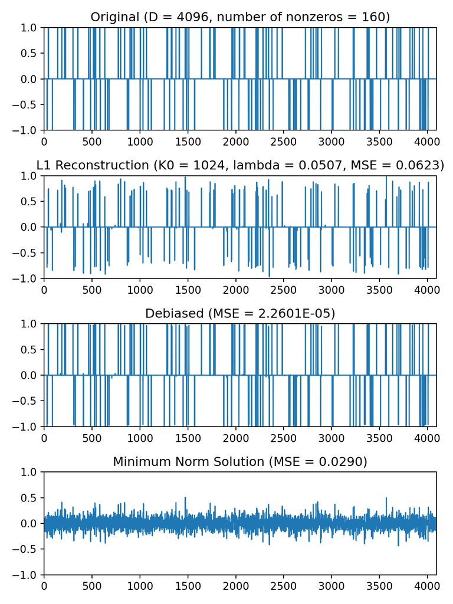

```python
fig.tight_layout()

plt.show()
```

# 3 LAB-SGPE: Inferration Ideology Scores from Campain Contribution Using Lasso and Elastic Net

```r
load("/Users/duongtrinh/Dropbox/FIELDS/Machine Learning/Courses/[2022] SGPE Summer School/Tutorials/1_Lasso_Ideology/Ideology_data.RData")

x.train <- sml.data$x.train
y.train <- sml.data$y.train
rm(sml.data)
```